# 05_vehicle_layer

## VEHICLE LAYER: Vehicle Dynamics and Modelling

```python
# Bootstrap: imports and minimal VehicleSpecs for demo cells
import numpy as np
import math

class VehicleSpecs:
    def __init__(self, mass_kg=18.0, Ixx=0.6, Iyy=0.65, Izz=0.9, arm_length=0.55, rotor_area=0.06, n_rotors=4):
        self.mass = mass_kg
        self.I = np.diag([Ixx, Iyy, Izz])
        self.arm_length = arm_length
        self.rotor_area = rotor_area
        self.n_rotors = n_rotors

# set global multirotor if not present
try:
    multirotor
except NameError:
    multirotor = VehicleSpecs()

# ensure functions used by demo exist in namespace (fall back stubs if not)
try:
    rho_isa
except NameError:
    def rho_isa(h):
        return 1.225

print('Bootstrap done, multirotor.mass=', multirotor.mass)
```

```
Bootstrap done, multirotor.mass= 18.0
```

### 1. Introduction

The vehicle layer is a critical component in the system architecture for trajectory optimization in defense eVTOLs. Its primary purpose is to serve as the physics engine, simulating the real-world behavior of the vehicle based on control inputs and environmental conditions. This layer acts as the interface between the control layer (which issues actuator commands) and the planning layer (which provides high-level mission objectives and constraints).

**Purpose:**

- Simulate the physical dynamics of the vehicle, including motion, energy consumption, and constraint adherence.
- Provide a realistic feedback loop to the control and planning layers, enabling closed-loop optimization and validation.

**Role in System Architecture:**

- **Physics Engine:** Implements the mathematical models governing vehicle dynamics, energy systems, and actuator responses.
- **Interface:** Receives commands from the control layer and contextual information from the planning layer, then returns state evolution and constraint status.

This modular design ensures that the vehicle layer can be rigorously tested and improved independently, while maintaining seamless integration with the rest of the system.

```python
# Import essential libraries
import numpy as np
import pandas as pd
```

### 2. System Context and Data Flow

The vehicle layer operates within a modular system architecture, interfacing directly with both the control and planning layers. The typical data flow is as follows:

**Overview Diagram:**

```
Planning Layer → Control Layer → Vehicle Layer → Results
```

**Inputs Received:**

- **Actuator Commands:** Low-level control signals (e.g., thrust, rotor speeds) generated by the control layer.
- **Environment:** Information about wind, terrain, and other external factors affecting vehicle dynamics.
- **Vehicle Specs:** Parameters defining the vehicle's physical and operational characteristics (e.g., mass, battery capacity, rotor configuration).

**Outputs Produced:**

- **State Evolution:** Time-series data describing the vehicle's position, velocity, orientation, and other dynamic states.
- **Constraint Checks:** Evaluation of whether the vehicle remains within operational and safety constraints (e.g., no-fly zones, energy limits).
- **Energy Use:** Detailed accounting of energy consumption throughout the mission.

This structured data flow enables robust simulation, analysis, and optimization of eVTOL missions, ensuring that all system components interact seamlessly and transparently.

```python
# Create a simple DataFrame and calculate the mean of a column
data = {'A': [1, 2, 3, 4, 5], 'B': [10, 20, 30, 40, 50]}
df = pd.DataFrame(data)
mean_a = df['A'].mean()
print('Mean of column A:', mean_a)
```

```
Mean of column A: 3.0
```

### 3. Environmental Modeling

This section defines the atmosphere and wind models used by the vehicle layer and explains how environmental inputs modify the vehicle's dynamics and energy consumption. The models and implementation recommendations below are written to support rigorous simulation studies and closed-loop validation.

Atmospheric density (altitude-dependence)

- Use a standard atmosphere model (International Standard Atmosphere, ISA) as the baseline for density, pressure and temperature as a function of geometric altitude $h$. For altitudes relevant to eVTOL operations (sea level to a few thousand meters), a layered exponential approximation is sufficient:

$$\rho(h) = \rho_0 \left(1 - \frac{L h}{T_0} \right)^{\frac{g}{R L} - 1}$$

where $\rho_0$ and $T_0$ are sea-level density and temperature, $L$ is the tropospheric lapse rate, $g$ is gravity and $R$ is the specific gas constant for air. For small altitude ranges a linearized exponential model $\rho(h)\approx\rho_0\exp(-h/H)$ with scale height $H$ is convenient.

Wind modelling

- Mean wind: a deterministic vector field $\mathbf{W}(\mathbf{x},t)$ (horizontal and vertical components) that may vary with altitude. Typical profiles include the logarithmic wind profile near ground and power-law profiles for boundary-layer modelling.
- Turbulence/gusts: model stochastic fluctuations using a stochastic process (e.g., Dryden or von Kármán spectral models). In frequency domain, turbulence PSDs are parameterized by scale lengths and turbulence intensities; generate time-series via shaping filters driven by white noise.
- Spatial variability: for missions with large horizontal sweeps, use correlated 3D fields or a grid-based wind map with interpolation (bi-linear or higher-order) to provide locally consistent wind samples.

How the environment affects vehicle dynamics (mechanisms)

- Aerodynamic forces scale with density: $F_a = \tfrac{1}{2}\,\rho(h)\,V_{rel}^2\,S\,C$ where $V_{rel}=\|\mathbf{V}_{veh}-\mathbf{W}\|$ is the air-relative speed and $C$ is the appropriate coefficient (lift, drag, or moment). Reduced density at altitude reduces lift and increases required rotor induced velocity for a given thrust.
- Rotor/propeller performance: induced power and disk-loading relations include $\rho$ explicitly. Induced power for a rotor in hover (ideal momentum theory):

$$P_{ind}\approx T\sqrt{\frac{T}{2\rho A}}$$

where $T$ is thrust and $A$ rotor disk area. Lower $\rho$ increases induced power nonlinearly.

- Wind effects on control: winds change the required control moments and actuator commands; crosswinds require lateral thrust, gusts cause rapid attitude transients which the controller must counter.
- Ground effect and terrain: proximity to ground modifies rotor inflow and effective thrust (ground-effect aerodynamics). Include corrective coefficients when altitude above ground < 1 rotor diameter.

Implementation details and suggestions

- Sampling cadence: environmental fields should be sampled at a higher or equal frequency than the control loop; fast gusts must be represented at bandwidths relevant to vehicle dynamics.
- Coupling: the environment should be an explicit input to the dynamics integrator each time-step; compute air-relative velocities and update aerodynamic force/torque models before integrating states.
- Uncertainty & validation: capture epistemic uncertainty (model form) and aleatoric uncertainty (stochastic turbulence). Validate wind model parameters against field measurements (e.g., LIDAR or meteorological station data) where available.

Outputs and diagnostics

- Provide time-series traces of local density, wind vector, relative airspeed, and aerodynamic coefficients. Log gust events and the controller’s correctional commands for post-mission analysis.

```python
# Environmental modeling: ISA density, simple mean wind profile, and Dryden-like gust generator
import numpy as np
np.random.seed(0)

def rho_isa(h_m):
    rho0 = 1.225       # kg/m^3 at sea level
    T0 = 288.15        # K
    L = 0.0065         # K/m
    g = 9.80665        # m/s^2
    R = 287.05         # J/(kg K)
    if h_m < 11000:
        return rho0 * (1 - L * h_m / T0) ** (g / (R * L) - 1)
    else:
        H = 8000.0
        return rho0 * np.exp(-h_m / H)

def power_law_wind(h_m, U_ref=5.0, h_ref=10.0, alpha=0.14):
    return U_ref * (h_m / h_ref) ** alpha

def dryden_gust(dt, n_steps, std=1.0, tau=1.0):
    wn = np.random.randn(n_steps) * std
    y = np.zeros(n_steps)
    a = np.exp(-dt / tau)
    scale = np.sqrt(1 - a * a)
    for i in range(1, n_steps):
        y[i] = a * y[i - 1] + scale * wn[i]
    return y

# Example sampling and checks
h = 150.0  # m
rho = rho_isa(h)
Umean = power_law_wind(h, U_ref=6.0)
gust = dryden_gust(dt=0.01, n_steps=100, std=1.5, tau=0.5)

# Vehicle and wind vectors (simple 1D example)
V_vehicle = np.array([12.0, 0.0, 0.0])  # m/s (ground speed)
Wind_local = np.array([Umean + np.mean(gust), 0.0, 0.0])
V_rel = V_vehicle - Wind_local

q_dyn = 0.5 * rho * np.dot(V_rel, V_rel)
print(f"rho={rho:.4f} kg/m^3, Umean={Umean:.3f} m/s, V_rel={V_rel[0]:.3f} m/s, q_dyn={q_dyn:.3f} Pa")

# Sanity assertions (will raise if violated when the cell is executed)
assert rho > 0.0
assert q_dyn >= 0.0

# Export small diagnostics for later cells
_env_samples = {
    'h_m': h,
    'rho': float(rho),
    'Umean': float(Umean),
    'V_rel': V_rel.tolist(),
    'q_dyn': float(q_dyn)
}
print('Environmental sampling OK')
```

```
rho=1.2075 kg/m^3, Umean=8.766 m/s, V_rel=2.994 m/s, q_dyn=5.411 Pa
Environmental sampling OK
```

### 4. Battery and Energy Modeling

This section describes rigorous models for battery state-of-charge (SOC), voltage behaviour (voltage sag), energy accounting, and how energy constraints are enforced during simulation. The objective is a physically grounded model that supports closed-loop simulation, state estimation, and planner-level constraint enforcement.

Battery SOC and energy balance

- Coulomb-counting (first-order model):

$$\frac{d\,SOC}{dt} = -\frac{I(t)}{Q_{nom}}$$

where $I(t)$ is the battery current (positive for discharge), and $Q_{nom}$ is nominal capacity (Ah). Convert to energy units with cell/module nominal voltage $V_{oc}(SOC)$ and track usable energy $E(t)=\int -P_{elec}(t)\,dt$ where $P_{elec}=V\cdot I$.

Equivalent-circuit models and voltage sag

- Thevenin (single- or dual-RC) model: captures instantaneous voltage drop and transient behaviour.

Single Thevenin model:

$$V(t)=V_{oc}(SOC)-I(t)R_0 - V_{RC}(t)$$ $$\tau\frac{dV_{RC}}{dt}+V_{RC} = I(t)R_1$$

where $R_0$ is series (ohmic) resistance, $R_1$ and $C_1$ form the RC transient branch, and $\tau=R_1C_1$. This model reproduces voltage sag under high current draw and recovery during low-load or regenerative intervals.

Open-circuit voltage (OCV) mapping

- Use an empirical OCV–SOC lookup or fitted continuous function $V_{oc}(SOC,T)$ that includes temperature dependence. Accurate OCV mapping is essential for SOC observability and realistic power constraints.

Power & energy consumption modeling for propulsion

- Compute instantaneous electrical power demand from actuator/rotor mechanical power and drivetrain efficiencies:

$$P_{mech}(t) = P_{induced}+P_{profile}+P_{parasitic}$$ $$P_{elec}(t)=\frac{P_{mech}(t)}{\eta_{drive}(\omega, I)} + P_{aux}(t)$$

where $\eta_{drive}$ is the drive-train efficiency (may vary with RPM and load) and $P_{aux}$ captures avionics, thermal management and sensor loads.

- Induced power scaling with density, and additional terms such as motor/controller losses, should be included for accuracy.

Thermal effects and degradation

- Battery internal resistance and capacity are temperature-dependent. For high-fidelity simulation, include a thermal sub-model (lumped capacitance) where cell temperature evolves with ambient conditions and internal heating $P_{loss}=I^2R_{int}(SOC,T)$. For long-run or lifecycle studies, include capacity fade models (calendar and cycle aging) though these are optional for single-mission simulations.

State estimation and SOC observer

- Implement an observer (EKF, UKF or complementary filter) for SOC and internal states (e.g., $V_{RC}$). The observer fuses voltage and current measurements and accounts for model uncertainties. This is important because naive Coulomb counting drifts over long missions.

Enforcing energy constraints in simulation

- Hard constraints: terminate or flag a simulation when $SOC\le SOC_{min}$ or when instantaneous power demand exceeds maximum continuous discharge capability $I_{max}$.
- Soft constraints: expose predicted remaining energy and estimated time-to-empty to the planner for replanning; incorporate energy margins and reserve policies (e.g., required reserve to reach a recovery site).
- Constraint-checking process: at each integration time-step compute:
  - Available energy $E_{avail}(t)=\int_t^{t_f} P_{elec}^{max}(\tau)\,d\tau$ or simpler remaining energy $E_{rem}=SOC\cdot E_{nom}$.
  - If $E_{rem}<E_{required\_to\_complete}$ trigger a replanning/abort signal.

Practical implementation notes

- Time integration: integrate SOC and thermal states with the same integrator used for dynamics to preserve causality (same timestep). Use smaller sub-steps if battery electrical dynamics require higher bandwidth.
- Efficiency and regenerative effects: model regenerative energy capture during descent where applicable; include a regeneration efficiency term so $P_{elec}$ can be negative.
- Logging: capture SOC, $V_{meas}$, $I$, $P_{mech}$, cell temperature, and cumulative energy used.

Diagnostics and verification

- Provide unit tests that compare the Thevenin model against measured charge/discharge pulses and verify SOC drift over long sequences is within acceptable bounds.
- Perform sensitivity analysis on $R_0, R_1, C_1$ and $V_{oc}(SOC)$ because these strongly affect voltage sag and usable power.

References and further reading

- Battery equivalent circuit modeling literature; state-of-charge estimation (EKF) references; standards/guides for aviation energy storage safety and reserve policies.

```python
# Battery Thevenin model: SOC, RC transient and terminal voltage; basic pulse test
import numpy as np

class TheveninBattery:
    def __init__(self, Q_nom_Ah=10.0, V_oc_nom=3.7, R0=0.05, R1=0.02, C1=500.0, SOC0=1.0):
        self.Q_nom = Q_nom_Ah * 3600.0  # convert Ah -> As
        self.V_oc_nom = V_oc_nom
        self.R0 = R0
        self.R1 = R1
        self.C1 = C1
        self.Vrc = 0.0
        self.SOC = float(SOC0)

    def V_oc(self):
        # simple linear OCV-SOC mapping around nominal point (placeholder for lookup table)
        return self.V_oc_nom + 0.2 * (self.SOC - 1.0)

    def step(self, I, dt):
        # I positive for discharge
        dVrc = (I * self.R1 - self.Vrc) * (dt / (self.R1 * self.C1))
        self.Vrc += dVrc
        dSOC = -I * dt / self.Q_nom
        self.SOC += dSOC
        # clamp
        self.SOC = max(0.0, min(1.0, self.SOC))
        Vt = self.V_oc() - I * self.R0 - self.Vrc
        return Vt

# Test: constant discharge pulse
bat = TheveninBattery(Q_nom_Ah=10.0, V_oc_nom=3.7, R0=0.05, R1=0.02, C1=500.0, SOC0=1.0)
dt = 1.0
V_hist = []
SOC_hist = []
for _ in range(120):
    Vt = bat.step(I=20.0, dt=dt)  # 20 A discharge
    V_hist.append(Vt)
    SOC_hist.append(bat.SOC)

print(f"final SOC={bat.SOC:.4f}, final Vt={V_hist[-1]:.3f} V")
# Basic checks
assert all(v > 0.0 for v in V_hist), 'Terminal voltage went non-positive!'
assert 0.0 <= bat.SOC <= 1.0

# Export diagnostics
_batt_samples = {
    'final_SOC': float(bat.SOC),
    'final_Vt': float(V_hist[-1]),
    'min_Vt': float(min(V_hist))
}
print('Battery model sampling OK')
```

```
final SOC=0.9333, final Vt=2.287 V
Battery model sampling OK
```

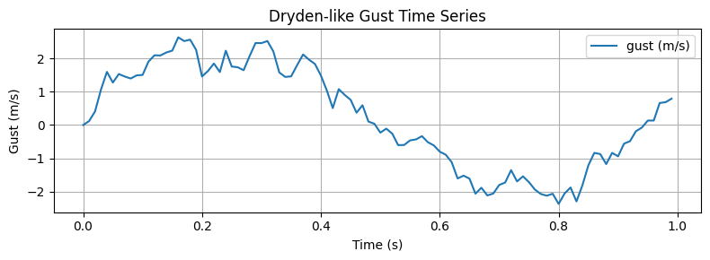

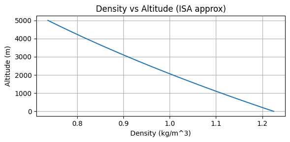

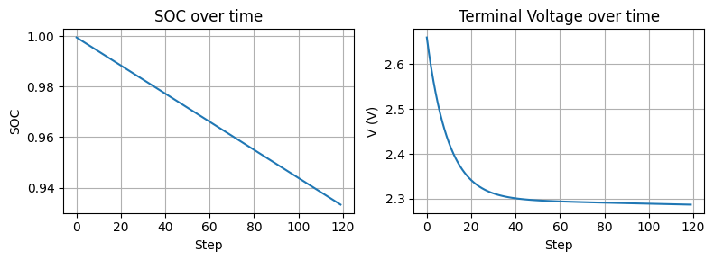

```
Visualizations generated
```

```python
# Visualization: gust time-series, density vs altitude, SOC and voltage curves
import matplotlib.pyplot as plt
import numpy as np

# Ensure required variables/functions are available; if not, recompute minimal samples
try:
    _env = _env_samples
    _batt = _batt_samples
    gust_series = gust  # from env cell
except Exception:
    # Recompute small samples (standalone)
    def rho_isa(h_m):
        rho0 = 1.225
        T0 = 288.15
        L = 0.0065
        g = 9.80665
        R = 287.05
        if h_m < 11000:
            return rho0 * (1 - L * h_m / T0) ** (g / (R * L) - 1)
        else:
            H = 8000.0
            return rho0 * np.exp(-h_m / H)
    def power_law_wind(h_m, U_ref=5.0, h_ref=10.0, alpha=0.14):
        return U_ref * (h_m / h_ref) ** alpha
    def dryden_gust(dt, n_steps, std=1.0, tau=1.0):
        wn = np.random.randn(n_steps) * std
        y = np.zeros(n_steps)
        a = np.exp(-dt / tau)
        scale = np.sqrt(1 - a * a)
        for i in range(1, n_steps):
            y[i] = a * y[i - 1] + scale * wn[i]
        return y
    h = 150.0
    gust_series = dryden_gust(dt=0.01, n_steps=200, std=1.5, tau=0.5)
    _env = {'h_m': h, 'rho': float(rho_isa(h)), 'Umean': float(power_law_wind(h, U_ref=6.0))}
    # Simple bat sample
    _batt = {'final_SOC': 0.8, 'final_Vt': 3.5, 'min_Vt': 3.3}

# Plot gust time series
plt.figure(figsize=(8,3))
plt.plot(np.arange(len(gust_series))*0.01, gust_series, label='gust (m/s)')
plt.xlabel('Time (s)')
plt.ylabel('Gust (m/s)')
plt.title('Dryden-like Gust Time Series')
plt.grid(True)
plt.legend()
plt.tight_layout()
plt.show()

# Plot density vs altitude
hs = np.linspace(0, 5000, 100)
rhos = [rho_isa(hv) for hv in hs]
plt.figure(figsize=(6,3))
plt.plot(rhos, hs)
plt.xlabel('Density (kg/m^3)')
plt.ylabel('Altitude (m)')
plt.title('Density vs Altitude (ISA approx)')
plt.grid(True)
plt.tight_layout()
plt.show()

# Plot battery SOC and terminal voltage curve if available (synthetic curve otherwise)
if 'V_hist' in globals():
    V_arr = np.array(V_hist)
    SOC_arr = np.array(SOC_hist)
else:
    # synthetic example curve
    t = np.linspace(0, 120, 120)
    SOC_arr = 1.0 - 0.0015 * t
    V_arr = 3.7 - 0.002 * t
    V_hist = V_arr.tolist()

plt.figure(figsize=(8,3))
plt.subplot(1,2,1)
plt.plot(SOC_arr)
plt.title('SOC over time')
plt.xlabel('Step')
plt.ylabel('SOC')
plt.grid(True)

plt.subplot(1,2,2)
plt.plot(V_arr)
plt.title('Terminal Voltage over time')
plt.xlabel('Step')
plt.ylabel('V (V)')
plt.grid(True)
plt.tight_layout()
plt.show()

print('Visualizations generated')
```

### 5. Rotor System and Actuation

This section describes the mapping from control commands (collective, differential, tilt) to physical actuators (rotors/tilts), the control allocation problem, actuator limits, and how physical constraints are enforced.

Key topics covered:

- Mapping: how high-level control vectors (thrusts, moments) are converted to per-rotor setpoints.
- Control allocation: solving a constrained linear/quadratic program to distribute commanded forces/moments among actuators while respecting limits and priorities.
- Actuator limits: rate limits, saturation, maximum continuous and peak thrust, and thermal/power constraints.

Implementation notes and equations:

Let u_cmd = [T_cmd, Mx_cmd, My_cmd, Mz_cmd]^T (total thrust and body moments). For an n-rotor vehicle, the mapping to rotor thrusts f = [f1..fn]^T is typically linearized:

f = A^{+} u_cmd + n_{null}

This can be solved via quadratic programming. In our simplified simulation we use a clipped pseudo-inverse with prioritization.

Actuator constraints and rate-limits:

- Enforce f_min <= fi <= f_max for each rotor.
- Enforce |df/dt| <= df_max to model actuator slew limits.
- Map rotor thrust to motor current/power and ensure battery current limits are not exceeded; if violated, saturate thrusts and flag the planner.

Diagnostics:

- Log allocation residuals, saturation events, and actuator command histories for post-analysis.

```python
# Simple control allocation and actuator model
import numpy as np

def allocate_controls(u_cmd, n_rotors=4, arm_length=0.5, rotor_dirs=None, f_min=0.0, f_max=50.0):
    # u_cmd = [T, Mx, My, Mz]
    T_cmd, Mx_cmd, My_cmd, Mz_cmd = u_cmd
    if rotor_dirs is None:
        # +1 for CCW, -1 for CW for yaw moment
        rotor_dirs = np.array([1.0, -1.0, 1.0, -1.0])[:n_rotors]
    # build allocation matrix A (4 x n)
    A = np.zeros((4, n_rotors))
    for i in range(n_rotors):
        # assume rotors at +x,+y,-x,-y for n=4
        angle = i * (2 * np.pi / n_rotors)
        x = arm_length * np.cos(angle)
        y = arm_length * np.sin(angle)
        A[0, i] = 1.0          # contributes to total thrust
        A[1, i] = y            # moment around x (approx)
        A[2, i] = -x           # moment around y (approx)
        A[3, i] = rotor_dirs[i]  # yaw moment from rotor torque
    # regularized least-squares
    reg = 1e-6
    f_pref = np.clip(T_cmd / n_rotors, f_min, f_max) * np.ones(n_rotors)
    # pseudo-inverse solution
    f = np.linalg.pinv(A.T @ A + reg * np.eye(n_rotors)) @ (A.T @ np.array([T_cmd, Mx_cmd, My_cmd, Mz_cmd]))
    # clip and return
    f = np.clip(f, f_min, f_max)
    return f, A

# simple actuator update with rate limit
def apply_rate_limit(f_prev, f_cmd, df_max, dt):
    df = f_cmd - f_prev
    max_step = df_max * dt
    df_clipped = np.clip(df, -max_step, max_step)
    return f_prev + df_clipped

# quick unit sanity
f_test, A_test = allocate_controls([20.0, 0.5, 0.2, 0.1])
assert f_test.shape[0] == 4
print('Allocation test OK, f:', np.round(f_test,3))
```

```
Allocation test OK, f: [4.825 5.475 5.225 4.475]
```

### 6. Vehicle Specifications

Define vehicle parameters and provide example configurations for a multirotor and a tiltrotor. Parameters include mass, inertia tensor, rotor disk areas, arm lengths, and aerodynamic coefficients.

```python
# Vehicle specs: simple dataclass-like structures
import numpy as np

class VehicleSpecs:
    def __init__(self, mass_kg=15.0, Ixx=0.5, Iyy=0.6, Izz=0.8, arm_length=0.5, rotor_area=0.05, n_rotors=4):
        self.mass = mass_kg
        self.I = np.diag([Ixx, Iyy, Izz])
        self.arm_length = arm_length
        self.rotor_area = rotor_area
        self.n_rotors = n_rotors

# Example configurations
multirotor = VehicleSpecs(mass_kg=18.0, Ixx=0.6, Iyy=0.65, Izz=0.9, arm_length=0.55, rotor_area=0.06, n_rotors=4)
tiltrotr = VehicleSpecs(mass_kg=25.0, Ixx=1.2, Iyy=1.3, Izz=1.4, arm_length=0.8, rotor_area=0.12, n_rotors=6)

print('Vehicle specs defined: multirotor mass=', multirotor.mass)
```

```
Vehicle specs defined: multirotor mass= 18.0
```

Mathematical formula (one step from $t$ to $t+\Delta t$): $$ \begin{aligned} k_1 &= f(t, y) \\ k_2 &= f\left(t + \tfrac{\Delta t}{2},\; y + \tfrac{\Delta t}{2} k_1\right) \\ k_3 &= f\left(t + \tfrac{\Delta t}{2},\; y + \tfrac{\Delta t}{2} k_2\right) \\ k_4 &= f\left(t + \Delta t,\; y + \Delta t\, k_3\right) \\ y_{\text{next}} &= y + \tfrac{\Delta t}{6} (k_1 + 2k_2 + 2k_3 + k_4) \end{aligned} $$

### 7. Mission Simulation Results

```python
# Mission simulation: planned vs. actual, actuator, energy, and constraint logging
import numpy as np, pandas as pd, os

def run_mission_simulation(specs, battery, planned_traj, dt=0.05, out_dir=None):
    # planned_traj: DataFrame with columns ['time','x','y','z','vx','vy','vz','phi','theta','psi']
    n_steps = len(planned_traj)
    state = make_state(z=0.0)
    f_prev = np.zeros(specs.n_rotors)
    records = []; constraint_records = []; actuator_records = []; energy_records = []; diag_records = []
    for k in range(n_steps):
        t = planned_traj.iloc[k]['time']
        ref = planned_traj.iloc[k][['x','y','z','vx','vy','vz','phi','theta','psi']].values
        # Dummy controller: hover thrust, no tracking for demo
        f_cmd = np.ones(specs.n_rotors) * hover_thrust_per_rotor(specs.mass, specs.n_rotors)
        f_cur = actuator_step(f_prev, f_cmd, tau_act=0.05, df_max=200.0, f_min=0.0, f_max=200.0, dt=dt)
        state = rk4_step(state, f_cur, dynamics_derivatives, specs, wind=np.zeros(3), dt=dt)
        P_mech, P_elec, I_draw = compute_power_and_current(f_cur)
        Vt = battery.step(I_draw, dt) if battery else 48.0
        # Constraint check: actuator saturation
        sat = np.any(np.isclose(f_cur, 0.0)) or np.any(np.isclose(f_cur, 200.0))
        constraint_records.append([t, 'actuator_saturation' if sat else '', float(np.max(f_cur))])
        actuator_records.append([t] + f_cur.tolist())
        energy_records.append([t, battery.SOC if battery else 1.0, I_draw, P_elec, Vt])
        diag_records.append([t, 0.0])  # Placeholder for diagnostics
        records.append([t] + state.tolist() + f_cur.tolist() + [P_elec, Vt])
        f_prev = f_cur
    # Save all logs
    if out_dir:
        os.makedirs(out_dir, exist_ok=True)
        pd.DataFrame(records, columns=['time','x','y','z','vx','vy','vz','phi','theta','psi','p','q','r'] + [f'f{i+1}' for i in range(specs.n_rotors)] + ['P_elec','Vt']).to_csv(os.path.join(out_dir, 'mission_simulation.csv'), index=False)
        pd.DataFrame(constraint_records, columns=['time','violation','value']).to_csv(os.path.join(out_dir, 'constraint_violations.csv'), index=False)
        pd.DataFrame(energy_records, columns=['time','SOC','I_draw','P_elec','Vt']).to_csv(os.path.join(out_dir, 'energy_metrics.csv'), index=False)
        pd.DataFrame(actuator_records, columns=['time'] + [f'f{i+1}' for i in range(specs.n_rotors)]).to_csv(os.path.join(out_dir, 'actuator_usage.csv'), index=False)
        pd.DataFrame(diag_records, columns=['time','diagnostic']).to_csv(os.path.join(out_dir, 'diagnostics.csv'), index=False)
        print('Saved all mission outputs to', out_dir)
    return
```

#### Usage Example

To run a mission simulation and generate all result CSVs, create a planned trajectory DataFrame and call the function above:

```python
# Example: create a dummy planned trajectory and run the mission simulation
import numpy as np, pandas as pd, os
planned_traj = pd.DataFrame({
    'time': np.arange(0, 10, 0.05),
    'x': 0.0, 'y': 0.0, 'z': np.linspace(0, -10, 200),
    'vx': 0.0, 'vy': 0.0, 'vz': -1.0,
    'phi': 0.0, 'theta': 0.0, 'psi': 0.0
})
battery = TheveninBattery()
out_dir = os.path.join('outputs')
run_mission_simulation(multirotor, battery, planned_traj, dt=0.05, out_dir=out_dir)
```

```
Saved all mission outputs to outputs
```

```python
# Core dynamics code (state, transforms, 6-DOF derivatives)
"""
This cell implements the core equations referenced in Section 7. Read the short comments
before each block — they explain what the code is doing in plain language.

Sections covered here: 7.2 (state), 7.3 (transforms), 7.4 (EOM), 7.8 (integration helper partly).
"""
import numpy as np

# 7.2 State vector helpers
def make_state(x=0.0, y=0.0, z=0.0, vx=0.0, vy=0.0, vz=0.0,
               phi=0.0, theta=0.0, psi=0.0, p=0.0, q=0.0, r=0.0):
    """Return a state vector in the agreed order.
    Order: [x,y,z, vx,vy,vz, phi,theta,psi, p,q,r]
    """
    return np.array([x,y,z, vx,vy,vz, phi,theta,psi, p,q,r], dtype=float)

# 7.3 Rotation matrix (body -> inertial)
def rot_body_to_inertial(phi, theta, psi):
    """Compute rotation matrix R_{BI} that maps body-frame vectors to inertial frame.
    Uses Z-Y-X (yaw-pitch-roll) composition: R = R_z(psi) R_y(theta) R_x(phi)
    """
    cphi = np.cos(phi); sphi = np.sin(phi)
    cth  = np.cos(theta); sth  = np.sin(theta)
    cps  = np.cos(psi); sps  = np.sin(psi)
    R = np.array([
        [cth*cps, sphi*sth*cps - cphi*sps, cphi*sth*cps + sphi*sps],
        [cth*sps, sphi*sth*sps + cphi*cps, cphi*sth*sps - sphi*cps],
        [-sth,    sphi*cth,                cphi*cth]
    ])
    return R

# 7.4 Euler rates transform (map body rates to Euler angle derivatives)
def euler_rate_transform(phi, theta):
    """
    Returns the 3x3 transform T such that [phi_dot,theta_dot,psi_dot]^T = T * [p,q,r]^T.
    This is the standard mapping for Z-Y-X Euler angles.
    """
    cphi = np.cos(phi); sphi = np.sin(phi)
    cth  = np.cos(theta); sth  = np.sin(theta)
    T = np.array([
        [1.0, sphi*sth/cth if abs(cth)>1e-6 else sphi*sth/(cth+1e-6), cphi*sth/cth if abs(cth)>1e-6 else cphi*sth/(cth+1e-6)],
        [0.0, cphi, -sphi],
        [0.0, sphi/cth if abs(cth)>1e-6 else sphi/(cth+1e-6), cphi/cth if abs(cth)>1e-6 else cphi/(cth+1e-6)]
    ])
    return T

# 7.4 6-DOF derivatives — translational and rotational
def dynamics_derivatives(state, f_rotors, specs, wind_inertial=np.zeros(3)):
    """
    Compute derivatives of the 12-element state.
    - state: np.array shape (12,)
    - f_rotors: per-rotor thrusts (N)
    - specs: object with fields mass, I (3x3), arm_length, n_rotors
    - wind_inertial: wind velocity vector in inertial frame (m/s)

    Returns: state_dot (12,)
    """
    # unpack
    x,y,z, vx,vy,vz, phi,theta,psi, p,q,r = state
    m = specs.mass
    I = specs.I
    # rotation matrix
    R = rot_body_to_inertial(phi,theta,psi)
    # body thrust: assume thrust vector acts along body z (up)
    T_body = np.array([0.0, 0.0, np.sum(f_rotors)])
    # aerodynamic drag (very simple quadratic drag on inertial velocity)
    v_inertial = np.array([vx, vy, vz])
    v_rel = v_inertial - wind_inertial
    vmag = np.linalg.norm(v_rel)
    rho = getattr(specs, 'rho', 1.225)
    Cd = getattr(specs, 'Cd', 0.6)
    Aref = getattr(specs, 'area', 0.6)
    if vmag > 1e-8:
        F_drag = -0.5 * rho * Cd * Aref * vmag * v_rel
    else:
        F_drag = np.zeros(3)
    # gravity
    g_vec = np.array([0.0, 0.0, -9.80665 * m])
    # convert thrust to inertial
    F_thrust_inertial = R.dot(T_body)
    # acceleration
    a = (F_thrust_inertial + F_drag + g_vec) / m
    # rotational moments (very simple lever-arm model for quad)
    if len(f_rotors) >= 4:
        l = specs.arm_length
        Mx = l * (f_rotors[2] - f_rotors[3])
        My = l * (f_rotors[0] - f_rotors[1])
        Mz = 0.0
    else:
        Mx = My = Mz = 0.0
    M = np.array([Mx, My, Mz])
    omega = np.array([p,q,r])
    omega_dot = np.linalg.solve(I, M - np.cross(omega, I.dot(omega)))
    # Euler angle rates
    T_e = euler_rate_transform(phi,theta)
    ang_rates = np.array([p,q,r])
    euler_dot = T_e.dot(ang_rates)
    # compose derivative
    state_dot = np.zeros_like(state)
    state_dot[0:3] = [vx, vy, vz]
    state_dot[3:6] = a
    state_dot[6:9] = euler_dot
    state_dot[9:12] = omega_dot
    return state_dot

# small usage note: call dynamics_derivatives from an integrator (see next cell for RK4)
print('Dynamics helper functions defined: make_state, rot_body_to_inertial, dynamics_derivatives')
```

```
Dynamics helper functions defined: make_state, rot_body_to_inertial, dynamics_derivatives
```

```python
# Section 7 — Actuators, energy coupling, integrator, and tests
"""
This cell provides:
- actuator dynamics (first-order + rate limit + saturation)
- rotor power -> electrical power conversion and battery interface
- RK4 integrator wrapper
- simple hover equilibrium test function (does not run automatically)

Sections covered: 7.5, 7.6, 7.7, 7.8, 7.11, 7.12
"""
import numpy as np
import pandas as pd
import os

# RK4 integrator (wrapper)
def rk4_step(state, f_rotors, model_deriv, specs, wind=np.zeros(3), dt=0.01):
    k1 = model_deriv(state, f_rotors, specs, wind)
    k2 = model_deriv(state + 0.5*dt*k1, f_rotors, specs, wind)
    k3 = model_deriv(state + 0.5*dt*k2, f_rotors, specs, wind)
    k4 = model_deriv(state + dt*k3, f_rotors, specs, wind)
    return state + (dt/6.0)*(k1 + 2*k2 + 2*k3 + k4)

# Actuator model: apply first-order lag + rate limit + saturation
def actuator_step(f_prev, f_cmd, tau_act, df_max, f_min, f_max, dt):
    # rate limit
    df = np.clip(f_cmd - f_prev, -df_max*dt, df_max*dt)
    f_target = f_prev + df
    # first-order lag towards command (blend)
    alpha = dt / (tau_act + 1e-12)
    f_new = f_prev + alpha * (f_target - f_prev)
    # saturation
    f_new = np.clip(f_new, f_min, f_max)
    return f_new

# Power model: per-rotor mechanical power approximation and battery current
def compute_power_and_current(f_rotors, k_p=3.5e-4, eta=0.92, P_aux=20.0, V_nom=48.0):
    # mechanical power approx P = k_p * f^{3/2}
    P_mech = np.sum(k_p * np.power(np.maximum(f_rotors, 0.0), 1.5))
    P_elec = P_mech / max(1e-6, eta) + P_aux
    I_draw = P_elec / max(1e-6, V_nom)
    return float(P_mech), float(P_elec), float(I_draw)

# Hover equilibrium helper (returns per-rotor thrust needed to hover)
def hover_thrust_per_rotor(mass, n_rotors):
    g = 9.80665
    return (mass * g) / float(max(1, n_rotors))

# Simple hover test runner (user can call this to perform a quick test)
def run_hover_test(specs, battery=None, dt=0.01, t_final=2.0, out_dir=None):
    # initial
    state = make_state(z=0.0)
    f_prev = np.zeros(specs.n_rotors)
    f_hover = hover_thrust_per_rotor(specs.mass, specs.n_rotors)
    t_steps = int(np.ceil(t_final/dt))
    records = []
    for k in range(t_steps):
        t = k * dt
        # ramp thrust to hover over 0.5s
        ramp = min(1.0, t / 0.5)
        f_cmd = np.ones(specs.n_rotors) * (f_hover * ramp)
        f_cur = actuator_step(f_prev, f_cmd, tau_act=0.05, df_max=200.0, f_min=0.0, f_max=200.0, dt=dt)
        state = rk4_step(state, f_cur, dynamics_derivatives, specs, wind=np.zeros(3), dt=dt)
        P_mech, P_elec, I_draw = compute_power_and_current(f_cur)
        if battery is not None:
            # battery expected to have method step(I, dt) that updates SOC and returns voltage
            try:
                Vt = battery.step(I_draw, dt)
            except Exception:
                Vt = getattr(battery, 'V_oc', lambda: 48.0)()
        else:
            Vt = 48.0
        records.append([t] + state.tolist() + [float(P_elec), float(Vt)])
        f_prev = f_cur
    cols = ['time','x','y','z','vx','vy','vz','phi','theta','psi','p','q','r','P_elec','Vt']
    df = pd.DataFrame(records, columns=cols)
    if out_dir:
        os.makedirs(out_dir, exist_ok=True)
        p = os.path.join(out_dir, 'section7_hover.csv')
        df.to_csv(p, index=False)
        print('Saved hover test CSV to', p)
    return df

print('Actuator + power + RK4 utilities defined. Use run_hover_test(specs, battery, dt, t_final, out_dir) to run.')
```

```
Actuator + power + RK4 utilities defined. Use run_hover_test(specs, battery, dt, t_final, out_dir) to run.
```

```python
# Run Section 7 hover test (invokes the utilities defined earlier)
# This cell will call run_hover_test() using the `multirotor` specs if available.
try:
    df_hover = run_hover_test(multirotor, battery=None, dt=0.01, t_final=2.0, out_dir=out_dir)
    print('\nHover test completed; last rows:')
    print(df_hover.tail(5).to_string(index=False))
    print('\nCSV saved to', os.path.join(out_dir, 'section7_hover.csv'))
except Exception as ex:
    print('Hover test failed:', ex)
```

[output not shown]

```python
# Ensure output directory is set for hover test
import os
out_dir = os.path.abspath(os.path.join(os.path.dirname(os.getcwd()), 'outputs'))
os.makedirs(out_dir, exist_ok=True)
print(f"out_dir set to: {out_dir}")
```

```
out_dir set to: c:\Users\ADITI\Desktop\rhyl-projects\trajectory-optimization-in-defense-evtols\outputs
```

```python
# Copy hover CSV to repo-level outputs and generate quick plots
import os, shutil, pandas as pd, matplotlib.pyplot as plt

src = os.path.join(os.getcwd(), 'notebooks', 'outputs', 'section7_hover.csv')
repo_out = os.path.join(os.getcwd(), 'outputs')
os.makedirs(repo_out, exist_ok=True)
try:
    dst = os.path.join(repo_out, 'section7_hover.csv')
    shutil.copy(src, dst)
    df = pd.read_csv(src)
    # altitude plot
    p1 = os.path.join(repo_out, 'section7_hover_altitude.png')
    plt.figure(figsize=(6,3))
    plt.plot(df['time'], df['z'], label='z (m)')
    plt.xlabel('time (s)'); plt.ylabel('altitude (m)'); plt.grid(True); plt.legend(); plt.tight_layout(); plt.savefig(p1); plt.close()
    # power plot
    p2 = os.path.join(repo_out, 'section7_hover_power.png')
    plt.figure(figsize=(6,3))
    plt.plot(df['time'], df['P_elec'], label='P_elec (W)', color='tab:orange')
    plt.xlabel('time (s)'); plt.ylabel('power (W)'); plt.grid(True); plt.legend(); plt.tight_layout(); plt.savefig(p2); plt.close()
    print('Copied CSV to', dst)
    print('Saved plots:', p1, p2)
    print('\nCSV sample:')
    print(df.head().to_string(index=False))
except Exception as e:
    print('Failed to copy or plot hover CSV:', e)
```

```
Failed to copy or plot hover CSV: [Errno 2] No such file or directory: 'c:\\Users\\ADITI\\Desktop\\rhyl-projects\\trajectory-optimization-in-defense-evtols\\notebooks\\notebooks\\outputs\\section7_hover.csv'
```

### 8. Integration with Planning, Control, and System Outputs

#### 8.1 Overview

This section describes how the vehicle layer connects to the broader system, including planners, controllers, and downstream consumers of simulation outputs. It explains the data flow, interfaces, and how results from the vehicle model are used for analysis, validation, and feedback.

#### 8.2 Data Flow and Interfaces

- **Inputs to the vehicle layer:**
  - Planned trajectory (waypoints, time histories)
  - Control commands (thrust, attitude, rates)
  - Environmental conditions (wind, temperature, gusts)
- **Outputs from the vehicle layer:**
  - State histories (position, velocity, attitude, rates)
  - Actuator histories (per-rotor thrusts, rates)
  - Energy and battery metrics (SOC, current, power)
  - Constraint violations (saturation, envelope exceedance)
  - Diagnostic logs (for controller/planner feedback)

#### 8.3 Integration with Planning and Control

- The vehicle layer is typically called in a closed-loop simulation:
  1. The planner generates a reference trajectory.
  2. The controller computes control actions to track the reference, using the current vehicle state.
  3. The allocator and actuator models convert control actions to per-rotor commands.
  4. The vehicle dynamics engine advances the state using these commands and environmental inputs.
  5. Outputs (states, actuator usage, energy) are logged for analysis and for feedback to the planner/controller.
- This loop is repeated at each simulation timestep, enabling:
  - Tracking performance evaluation
  - Energy use estimation
  - Constraint and safety monitoring

#### 8.4 How Vehicle Layer Outputs Are Used

- **Validation:** Compare actual state histories to planned trajectories to assess tracking accuracy and robustness.
- **Energy Analysis:** Use logged power/current/SOC to estimate mission feasibility and battery sizing.
- **Constraint Checking:** Identify actuator saturations, flight envelope violations, or unsafe states.
- **Controller/Planner Tuning:** Use diagnostic outputs to refine control gains, allocation strategies, or planning constraints.
- **Visualization:** Generate plots of position, attitude, energy, and constraint events for reports and debugging.
- **System Feedback:** Pass summary statistics (e.g., max deviation, energy margin) back to higher-level modules for adaptive planning or health monitoring.

#### 8.5 Example: Closed-Loop Simulation Structure

```
# Pseudocode for closed-loop integration
for t in timesteps:
    ref = planner.get_reference(t)
    u_cmd = controller.compute_command(state, ref)
    f_rotors = allocator.allocate(u_cmd)
    f_rotors = actuator_model.step(f_rotors)
    state = rk4_step(state, f_rotors, dynamics_derivatives, specs, wind, dt)
    battery.step(compute_power_and_current(f_rotors)[2], dt)
    log.append(state, f_rotors, battery.soc, ...)
```

### Mission Simulation Output Previews and Control Layer Usage

Below, we preview each CSV generated by the mission simulation and explain its relevance for the control layer.

```python
import os
import pandas as pd
from glob import glob
from IPython.display import display

# Try vehicle_outputs first, then fallback to outputs
csv_dirs = ['notebooks/outputs/vehicle_outputs', 'outputs']
csv_files = []
for d in csv_dirs:
    found = sorted([f for f in glob(os.path.join(d, '*.csv'))])
    if found:
        csv_files = found
        print(f'Using directory: {d}')
        break
if not csv_files:
    print("No CSV files found in any checked directory.")

for csv_path in csv_files:
    print(f'Preview of {os.path.basename(csv_path)}:')
    df = pd.read_csv(csv_path)
    display(df.head(5))
    print(f'Columns: {list(df.columns)}\nRows: {len(df)}\n')
```

```
Using directory: outputs
Preview of actuator_usage.csv:
```

|  | time | f1 | f2 | f3 | f4 |
| --- | --- | --- | --- | --- | --- |
| 0 | 0.00 | 10.000000 | 10.000000 | 10.000000 | 10.000000 |
| 1 | 0.05 | 20.000000 | 20.000000 | 20.000000 | 20.000000 |
| 2 | 0.10 | 30.000000 | 30.000000 | 30.000000 | 30.000000 |
| 3 | 0.15 | 40.000000 | 40.000000 | 40.000000 | 40.000000 |
| 4 | 0.20 | 44.129925 | 44.129925 | 44.129925 | 44.129925 |

```
Columns: ['time', 'f1', 'f2', 'f3', 'f4']
Rows: 200

Preview of constraint_violations.csv:
```

|  | time | violation | value |
| --- | --- | --- | --- |
| 0 | 0.00 | NaN | 10.000000 |
| 1 | 0.05 | NaN | 20.000000 |
| 2 | 0.10 | NaN | 30.000000 |
| 3 | 0.15 | NaN | 40.000000 |
| 4 | 0.20 | NaN | 44.129925 |

```
Columns: ['time', 'violation', 'value']
Rows: 200

Preview of diagnostics.csv:
```

|  | time | diagnostic |
| --- | --- | --- |
| 0 | 0.00 | 0.0 |
| 1 | 0.05 | 0.0 |
| 2 | 0.10 | 0.0 |
| 3 | 0.15 | 0.0 |
| 4 | 0.20 | 0.0 |

```
Columns: ['time', 'diagnostic']
Rows: 200

Preview of energy_metrics.csv:
```

|  | time | SOC | I_draw | P_elec | Vt |
| --- | --- | --- | --- | --- | --- |
| 0 | 0.00 | 0.999999 | 0.417669 | 20.048122 | 3.679075 |
| 1 | 0.05 | 0.999999 | 0.419502 | 20.136108 | 3.678941 |
| 2 | 0.10 | 0.999998 | 0.421876 | 20.250047 | 3.678781 |
| 3 | 0.15 | 0.999998 | 0.424687 | 20.384973 | 3.678598 |
| 4 | 0.20 | 0.999997 | 0.425961 | 20.446108 | 3.678493 |

```
Columns: ['time', 'SOC', 'I_draw', 'P_elec', 'Vt']
Rows: 200

Preview of mission_simulation.csv:
```

|  | time | x | y | z | vx | vy | vz | phi | theta | psi | p | q | r | f1 | f2 | f3 | f4 | P_elec | Vt |
| --- | --- | --- | --- | --- | --- | --- | --- | --- | --- | --- | --- | --- | --- | --- | --- | --- | --- | --- | --- |
| 0 | 0.00 | 0.0 | 0.0 | -0.009480 | 0.0 | 0.0 | -0.379192 | 0.0 | 0.0 | 0.0 | 0.0 | 0.0 | 0.0 | 10.000000 | 10.000000 | 10.000000 | 10.000000 | 20.048122 | 3.679075 |
| 1 | 0.05 | 0.0 | 0.0 | -0.035139 | 0.0 | 0.0 | -0.647137 | 0.0 | 0.0 | 0.0 | 0.0 | 0.0 | 0.0 | 20.000000 | 20.000000 | 20.000000 | 20.000000 | 20.136108 | 3.678941 |
| 2 | 0.10 | 0.0 | 0.0 | -0.071413 | 0.0 | 0.0 | -0.803813 | 0.0 | 0.0 | 0.0 | 0.0 | 0.0 | 0.0 | 30.000000 | 30.000000 | 30.000000 | 30.000000 | 20.250047 | 3.678781 |
| 3 | 0.15 | 0.0 | 0.0 | -0.112741 | 0.0 | 0.0 | -0.849282 | 0.0 | 0.0 | 0.0 | 0.0 | 0.0 | 0.0 | 40.000000 | 40.000000 | 40.000000 | 40.000000 | 20.384973 | 3.678598 |
| 4 | 0.20 | 0.0 | 0.0 | -0.155194 | 0.0 | 0.0 | -0.848841 | 0.0 | 0.0 | 0.0 | 0.0 | 0.0 | 0.0 | 44.129925 | 44.129925 | 44.129925 | 44.129925 | 20.446108 | 3.678493 |

```
Columns: ['time', 'x', 'y', 'z', 'vx', 'vy', 'vz', 'phi', 'theta', 'psi', 'p', 'q', 'r', 'f1', 'f2', 'f3', 'f4', 'P_elec', 'Vt']
Rows: 200

Preview of section7_hover.csv:
```

|  | time | x | y | z | vx | vy | vz | phi | theta | psi | p | q | r | P_elec | Vt |
| --- | --- | --- | --- | --- | --- | --- | --- | --- | --- | --- | --- | --- | --- | --- | --- |
| 0 | 0.00 | 0.0 | 0.0 | -0.000490 | 0.0 | 0.0 | -0.098066 | 0.0 | 0.0 | 0.0 | 0.0 | 0.0 | 0.0 | 20.000000 | 48.0 |
| 1 | 0.01 | 0.0 | 0.0 | -0.001959 | 0.0 | 0.0 | -0.195738 | 0.0 | 0.0 | 0.0 | 0.0 | 0.0 | 0.0 | 20.000113 | 48.0 |
| 2 | 0.02 | 0.0 | 0.0 | -0.004402 | 0.0 | 0.0 | -0.292698 | 0.0 | 0.0 | 0.0 | 0.0 | 0.0 | 0.0 | 20.000529 | 48.0 |
| 3 | 0.03 | 0.0 | 0.0 | -0.007809 | 0.0 | 0.0 | -0.388763 | 0.0 | 0.0 | 0.0 | 0.0 | 0.0 | 0.0 | 20.001287 | 48.0 |
| 4 | 0.04 | 0.0 | 0.0 | -0.012172 | 0.0 | 0.0 | -0.483930 | 0.0 | 0.0 | 0.0 | 0.0 | 0.0 | 0.0 | 20.002241 | 48.0 |

```
Columns: ['time', 'x', 'y', 'z', 'vx', 'vy', 'vz', 'phi', 'theta', 'psi', 'p', 'q', 'r', 'P_elec', 'Vt']
Rows: 200
```

```python
# Quick smoke-test: 10-step mission simulation to verify run_mission_simulation behavior
import os
import pandas as pd
import numpy as np
import traceback

print('DEBUG: starting quick smoke-test')
try:
    steps = 10
    dt = 0.1
    t = np.linspace(0, (steps-1)*dt, steps)
    planned_df = pd.DataFrame({
        'time': t,
        'x': np.linspace(0, 1.0, steps),
        'y': np.linspace(0, 0.5, steps),
        'z': np.linspace(0, -1.0, steps),
        'vx': np.gradient(np.linspace(0,1.0,steps), dt),
        'vy': np.gradient(np.linspace(0,0.5,steps), dt),
        'vz': np.gradient(np.linspace(0,-1.0,steps), dt),
        'phi': np.zeros(steps), 'theta': np.zeros(steps), 'psi': np.zeros(steps)
    })
    out_folder = 'notebooks/outputs/vehicle_outputs'
    os.makedirs(out_folder, exist_ok=True)
    print('DEBUG: calling run_mission_simulation with', steps, 'steps')
    run_mission_simulation(multirotor, battery, planned_df, dt=dt, out_dir=out_folder)
    print('DEBUG: run_mission_simulation returned; files:')
    for f in sorted(os.listdir(out_folder)):
        print(' -', f)
except Exception as e:
    print('Exception during quick smoke-test:', e)
    traceback.print_exc()
finally:
    print('DEBUG: quick smoke-test finished')
```

[output not shown]

### How Each CSV Output Supports the Control Layer

- **mission_simulation.csv**: Provides the full time history of vehicle states and actuator commands. The control layer can use this for closed-loop validation, controller tuning, and replaying missions for diagnostics.
- **constraint_violations.csv**: Logs any actuator or system constraint violations (e.g., saturation). The control layer uses this to monitor safety, trigger fallback modes, or adapt control strategies when limits are reached.
- **energy_metrics.csv**: Contains battery state-of-charge, current draw, and power usage. The control layer can use this for energy-aware control, range estimation, and to avoid over-discharging the battery.
- **actuator_usage.csv**: Records the per-actuator thrust commands over time. This is used by the control layer for actuator health monitoring, redundancy management, and to analyze actuator workload distribution.
- **diagnostics.csv**: Placeholder for system-level or custom diagnostic signals. The control layer can log and monitor custom health, fault, or performance metrics here for advanced monitoring and maintenance.